# Age of Abalone

L92G09

P. Hoang, R. Nguyen, E. Su, B. Tran, J. Vaughan

Oct 20, 2024

## Problem Statement

- This project aims to develop regression models to accurately predict the age of abalone from physical measurements in order to find a more efficient way in comparison to the traditional techniques.
- **Traditional techniques** are time consuming involve cutting, staining and counting rings
- **Physical measurements** can potentially determine age easier

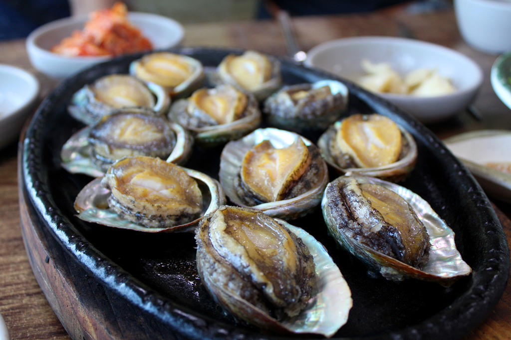

Abalone Platter

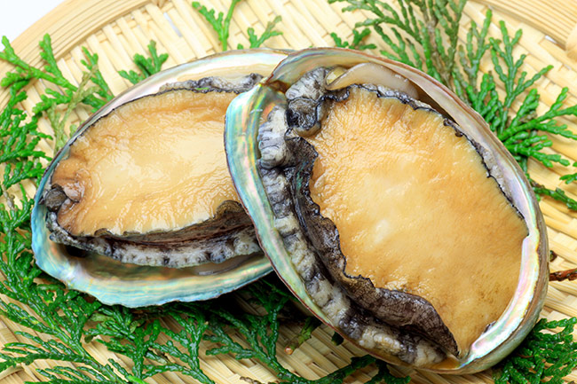

Cooked Abalone

## Background Information

- Abalone is a marine mollusk with a soft body and an ear-shaped shell, valued for both its meat and iridescent shell used in jewellery and ornaments.
- The dataset was compiled in November 1995
- No missing values are present (4177 samples collected)

| **Name** | **Data Type** | **Measurement Unit** | **Description** |
| --- | --- | --- | --- |
| Sex | nominal | – | M, F, and I (infant) |
| Length | continuous | mm | Longest shell measurement |
| Diameter | continuous | mm | Perpendicular to length |
| Height | continuous | mm | With meat in shell |
| Whole weight | continuous | grams | Whole abalone |
| Shucked weight | continuous | grams | Weight of meat |
| Viscera weight | continuous | grams | Gut weight (after bleeding) |
| Shell weight | continuous | grams | Weight after being dried |
| Rings | integer | – | +1.5 gives the age in years |

## Exploratory Data Analysis

- Scatterplot Matrix
- Correlation Matrix

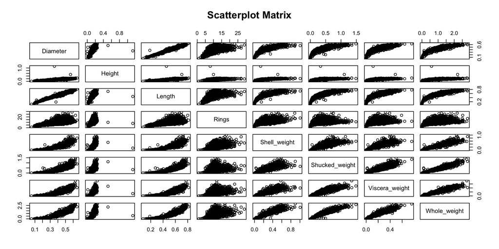

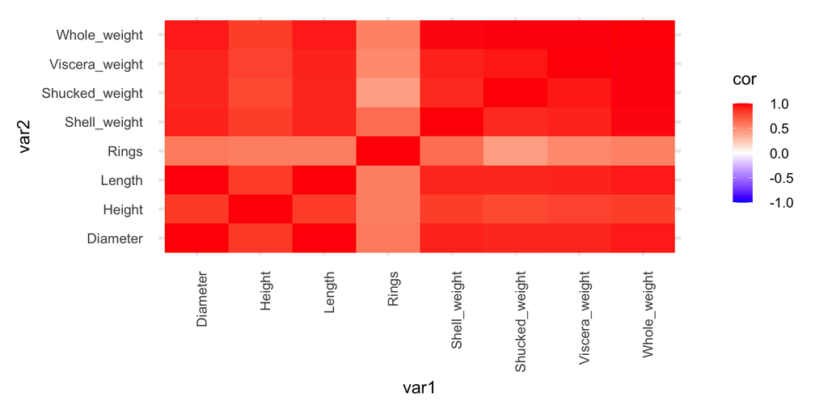

## Initial Models

**Null Model**

**Full model**

- Regression model containing all variables

|  | Null model |  | Full model |  |
| --- | --- | --- | --- | --- |
| Predictors | Estimates | p | Estimates | p |
| (Intercept) | 9.93 | **<0.001** | 3.89 | **<0.001** |
| Sex [I] |  |  | -0.82 | **<0.001** |
| Sex [M] |  |  | 0.06 | 0.489 |
| Length |  |  | -0.46 | 0.800 |
| Diameter |  |  | 11.08 | **<0.001** |
| Height |  |  | 10.76 | **<0.001** |
| Whole weight |  |  | 8.98 | **<0.001** |
| Shucked weight |  |  | -19.79 | **<0.001** |
| Viscera weight |  |  | -10.58 | **<0.001** |
| Shell weight |  |  | 8.74 | **<0.001** |
| Observations | 4177 |  | 4177 |  |
| R<sup>2</sup> / R<sup>2</sup> adjusted | 0.000 / 0.000 |  | 0.538 / 0.537 |  |
| AIC | 21636.633 |  | 18430.239 |  |

## Assumption Checking for full model

**Homoskedasticity**

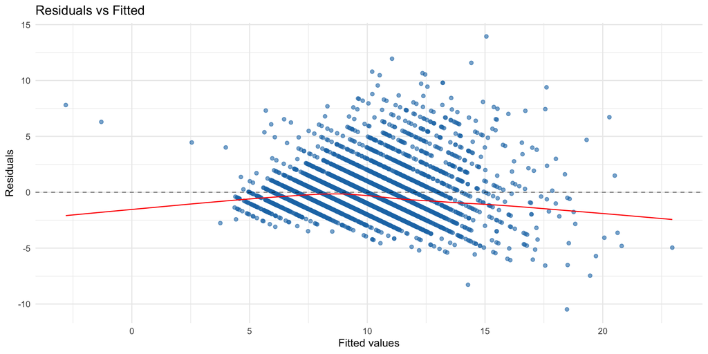

**Normality**

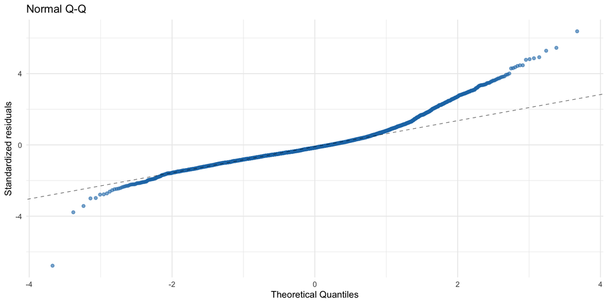

**Multicolinearity**

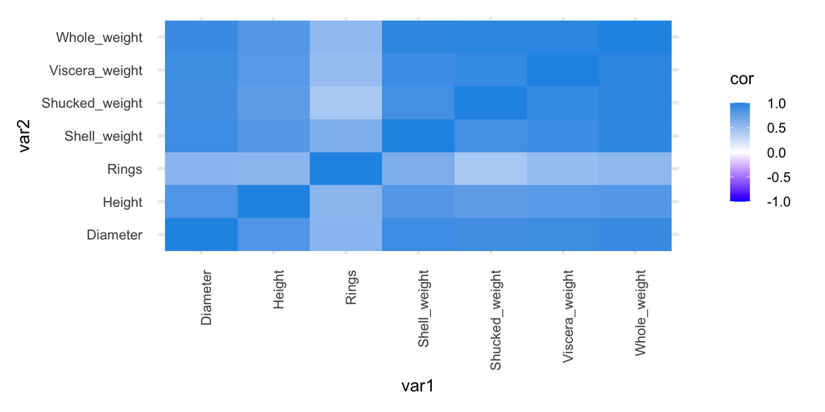

## Model Selection Techniques

**Forward Selection**

- Starts with no predictors
- Incrementally adds the most significant predictors one at a time based on a chosen criteria
- Continues until model reaches an optimal fit

**Backward Selection**

- Starts with all potential predictors
- Iteratively removes the least significant predictors one at a time based on a chosen criteria
- Continue an optimal model is achieved

**AIC and BIC Criteria**

- Used to compare and select models based on their goodness of fit penalising model complexity
- Smaller the value the better fitted the model.
- BIC has stronger penalty for the number of parameters.

## Forward Selection AIC & BIC (M1)

- Output
- Code

Regression Model Summary: Forward Selection (AIC)

| term | Coefficients estimate | Coefficients std.error | Coefficients statistic | Coefficients p.value |
| --- | --- | --- | --- | --- |
| (Intercept) | 3.8703828 | 0.2753641 | 14.0555108 | 7.06e-44 |
| Shell_weight | 8.7507754 | 1.1240479 | 7.7850557 | 8.73e-15 |
| Shucked_weight | -19.8025849 | 0.8149005 | -24.3006177 | 4.19e-122 |
| Diameter | 10.5695074 | 0.9888748 | 10.6884185 | 2.52e-26 |
| Whole_weight | 8.9775093 | 0.7252767 | 12.3780468 | 1.38e-34 |
| SexI | -0.8264414 | 0.1021973 | -8.0867250 | 7.96e-16 |
| SexM | 0.0575543 | 0.0833347 | 0.6906402 | 4.90e-01 |
| Viscera_weight | -10.6127867 | 1.2878199 | -8.2408936 | 2.27e-16 |
| Height | 10.7491050 | 1.5352466 | 7.0015493 | 2.94e-12 |

[output not shown]

Regression Model Summary: Forward Selection (BIC)

| term | Coefficients estimate | Coefficients std.error | Coefficients statistic | Coefficients p.value |
| --- | --- | --- | --- | --- |
| (Intercept) | 3.8703828 | 0.2753641 | 14.0555108 | 7.06e-44 |
| Shell_weight | 8.7507754 | 1.1240479 | 7.7850557 | 8.73e-15 |
| Shucked_weight | -19.8025849 | 0.8149005 | -24.3006177 | 4.19e-122 |
| Diameter | 10.5695074 | 0.9888748 | 10.6884185 | 2.52e-26 |
| Whole_weight | 8.9775093 | 0.7252767 | 12.3780468 | 1.38e-34 |
| SexI | -0.8264414 | 0.1021973 | -8.0867250 | 7.96e-16 |
| SexM | 0.0575543 | 0.0833347 | 0.6906402 | 4.90e-01 |
| Viscera_weight | -10.6127867 | 1.2878199 | -8.2408936 | 2.27e-16 |
| Height | 10.7491050 | 1.5352466 | 7.0015493 | 2.94e-12 |

[output not shown]

```r
full_model <- lm(Rings ~ ., data = abalone)
null_model <- lm(Rings ~ 1, data = abalone)
forward_model_aic <- step(null_model,
                          scope = list(lower = null_model, upper = full_model),
                          direction = "forward", trace = FALSE)
tidy_fma <- tidy(forward_model_aic) %>%
  mutate(p.value = formatC(p.value, format = "e", digits = 2))
tidy_fma %>%
  kable("html", caption = "Regression Model Summary: Forward Selection (AIC)") %>%
  kable_styling(bootstrap_options = c("striped", "hover", "condensed"), full_width = FALSE) %>%
  add_header_above(c(" " = 1, "Coefficients" = 4))
```

```r
n <- nrow(abalone)
k_bic <- log(n)
forward_model_bic <- step(null_model,
                          scope = list(lower = null_model, upper = full_model),
                          direction = "forward",
                          k = k_bic,
                          trace = FALSE)
tidy_fmb <- tidy(forward_model_bic) %>%
  mutate(p.value = formatC(p.value, format = "e", digits = 2))
tidy_fmb %>%
  kable("html", caption = "Regression Model Summary: Forward Selection (BIC)") %>%
  kable_styling(bootstrap_options = c("striped", "hover", "condensed"), full_width = FALSE) %>%
  add_header_above(c(" " = 1, "Coefficients" = 4))
```

**Regression Formula** $Rings=3.870+8.751\times Shell\_weight+(−19.803)\times Shucked\_weight+10.570\times \\ Diameter+8.978\times Whole\_weight+(−0.826)\times SexI+0.058\times SexM+(−10.613)\times \\ Viscera\_weight+10.749\times Height$

## Backward Selection AIC & BIC (M2)

- Output
- Code

Regression Model Summary: Backward Selection (AIC)

| term | Coefficients estimate | Coefficients std.error | Coefficients statistic | Coefficients p.value |
| --- | --- | --- | --- | --- |
| (Intercept) | 3.8703828 | 0.2753641 | 14.0555108 | 7.06e-44 |
| Shell_weight | 8.7507754 | 1.1240479 | 7.7850557 | 8.73e-15 |
| Shucked_weight | -19.8025849 | 0.8149005 | -24.3006177 | 4.19e-122 |
| Diameter | 10.5695074 | 0.9888748 | 10.6884185 | 2.52e-26 |
| Whole_weight | 8.9775093 | 0.7252767 | 12.3780468 | 1.38e-34 |
| SexI | -0.8264414 | 0.1021973 | -8.0867250 | 7.96e-16 |
| SexM | 0.0575543 | 0.0833347 | 0.6906402 | 4.90e-01 |
| Viscera_weight | -10.6127867 | 1.2878199 | -8.2408936 | 2.27e-16 |
| Height | 10.7491050 | 1.5352466 | 7.0015493 | 2.94e-12 |

[output not shown]

Regression Model Summary: Backward Selection (BIC)

| term | Coefficients estimate | Coefficients std.error | Coefficients statistic | Coefficients p.value |
| --- | --- | --- | --- | --- |
| (Intercept) | 3.8703828 | 0.2753641 | 14.0555108 | 7.06e-44 |
| Shell_weight | 8.7507754 | 1.1240479 | 7.7850557 | 8.73e-15 |
| Shucked_weight | -19.8025849 | 0.8149005 | -24.3006177 | 4.19e-122 |
| Diameter | 10.5695074 | 0.9888748 | 10.6884185 | 2.52e-26 |
| Whole_weight | 8.9775093 | 0.7252767 | 12.3780468 | 1.38e-34 |
| SexI | -0.8264414 | 0.1021973 | -8.0867250 | 7.96e-16 |
| SexM | 0.0575543 | 0.0833347 | 0.6906402 | 4.90e-01 |
| Viscera_weight | -10.6127867 | 1.2878199 | -8.2408936 | 2.27e-16 |
| Height | 10.7491050 | 1.5352466 | 7.0015493 | 2.94e-12 |

[output not shown]

```r
full_model <- lm(Rings ~ ., data = abalone)
null_model <- lm(Rings ~ 1, data = abalone)
backward_model_aic <- step(null_model,
                          scope = list(lower = null_model, upper = full_model),
                          direction = "backward", trace = FALSE)
tidy_fma <- tidy(forward_model_aic) %>%
  mutate(p.value = formatC(p.value, format = "e", digits = 2))
tidy_fma %>%
  kable("html", caption = "Regression Model Summary: Backward Selection (AIC)") %>%
  kable_styling(bootstrap_options = c("striped", "hover", "condensed"), full_width = FALSE) %>%
  add_header_above(c(" " = 1, "Coefficients" = 4))
```

```r
n <- nrow(abalone)
k_bic <- log(n)
backward_model_bic <- step(null_model,
                          scope = list(lower = null_model, upper = full_model),
                          direction = "backward",
                          k = k_bic,
                          trace = FALSE)
tidy_fmb <- tidy(forward_model_bic) %>%
  mutate(p.value = formatC(p.value, format = "e", digits = 2))
tidy_fmb %>%
  kable("html", caption = "Regression Model Summary: Backward Selection (BIC)") %>%
  kable_styling(bootstrap_options = c("striped", "hover", "condensed"), full_width = FALSE) %>%
  add_header_above(c(" " = 1, "Coefficients" = 4))
```

**Regression Formula** $Rings=3.870+8.751\times Shell\_weight+(−19.803)\times Shucked\_weight+10.570\times \\ Diameter+8.978\times Whole\_weight+(−0.826)\times SexI+0.058\times SexM+(−10.613)\times \\ Viscera\_weight+10.749\times Height$

## Intuitive Model (M3)

**Regression Formula**

$Rings=3.744+(−0.875)\times SexI+0.051\times SexM+10.847\times \\ Diameter+11.072\times Height +(−11.430)\times Shucked\_weight+ \\ (−0.796)\times Viscera\_weight+19.823\times Shell\_weight$

| Stat | Value |
| --- | --- |
| Residual Standard Error | 2.234 |
| Multiple R-Squared | 0.5209 |
| Adjusted R-Squared | 0.5201 |
| F-Statistic | 647.51 |
| p-value | 0 |

Regression Model Summary: Intuituve Model

| term | Coefficients estimate | Coefficients std.error | Coefficients statistic | Coefficients p.value |
| --- | --- | --- | --- | --- |
| (Intercept) | 3.7440337 | 0.2801533 | 13.3642321 | 6.42e-40 |
| SexI | -0.8749962 | 0.1039696 | -8.4158865 | 5.29e-17 |
| SexM | 0.0509983 | 0.0848406 | 0.6011065 | 5.48e-01 |
| Diameter | 10.8468156 | 1.0065071 | 10.7766902 | 9.95e-27 |
| Height | 11.0722136 | 1.5627964 | 7.0848725 | 1.63e-12 |
| Shucked_weight | -11.4296374 | 0.4626420 | -24.7051432 | 7.10e-126 |
| Viscera_weight | -0.7962922 | 1.0330203 | -0.7708389 | 4.41e-01 |
| Shell_weight | 19.8232080 | 0.6929868 | 28.6054630 | 1.76e-164 |

## Comparing model assumptions (Homoskedasticity)

- Residuals seem evenly spread out

**Forward Selection AIC**

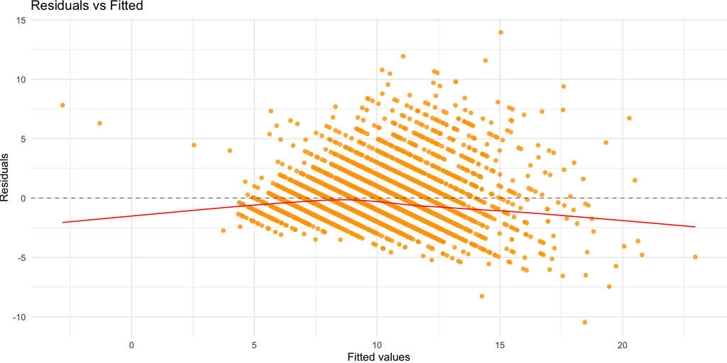

- Both models are relatively homoskedastic

**Intuitive Model**

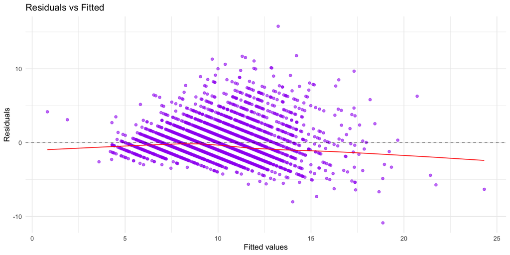

## Comparing model assumptions (Normality)

- Residuals fit the line, however, there are noticeable deviations at the end of the right and left tails.

**Forward Selection AIC**

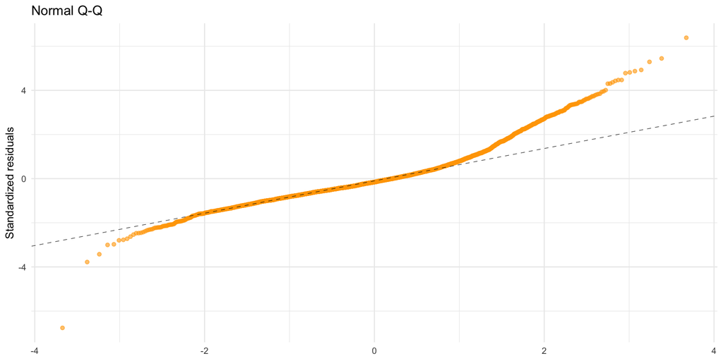

- Applying the central limit theorem (CLT) since the dataset is large enough (n > 30)

**Intuitive Model**

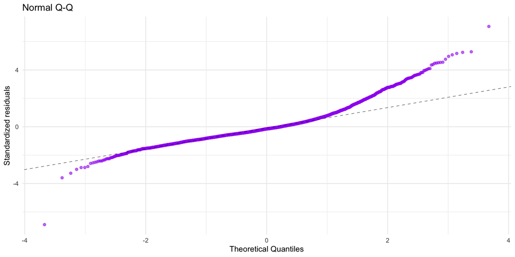

## Comparing model assumptions (multicollinearity)

**Forward Selection AIC**

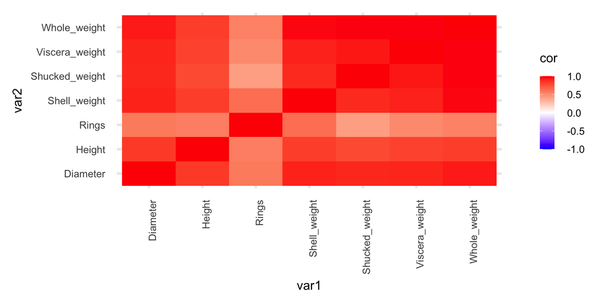

**Intuitive Model**

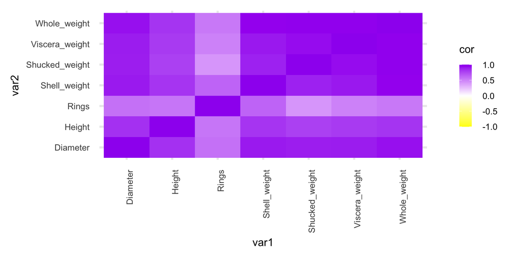

## Cross validation - Our models against full

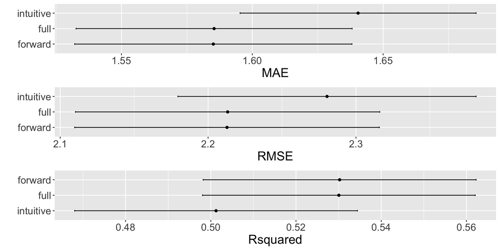

| Model | RMSE | MAE | Rsquared |
| --- | --- | --- | --- |
| Null Model | 3.221059 | 2.362453 | 0.0000000 |
| Full Model | 2.213232 | 1.585408 | 0.5300560 |
| Forward AIC | 2.212796 | 1.585108 | 0.5302374 |
| Backward AIC | 2.212796 | 1.585108 | 0.5302374 |
| Forward BIC | 2.212796 | 1.585108 | 0.5302374 |
| Backward BIC | 2.212796 | 1.585108 | 0.5302374 |
| Intuitive Model | 2.280414 | 1.640430 | 0.5012385 |

## Looking at Model Stability

- Highlights the impact of model complexity and penalization on stability.
- As penalization increases, model performance stabilizes, with simpler models showing higher consistency.
- These results emphasize the importance of balancing model complexity with generalization to improve robustness.

## Model Stability - Variable Inclusion Plots

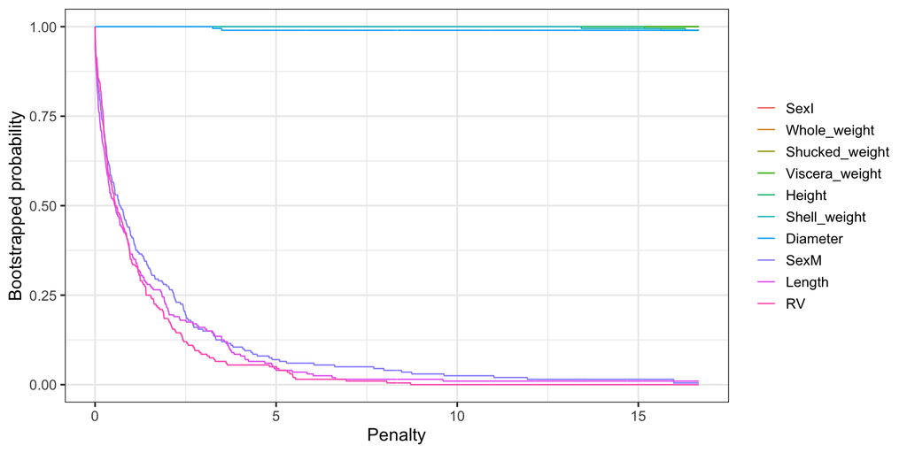

## Model Stability - Adaptive fence

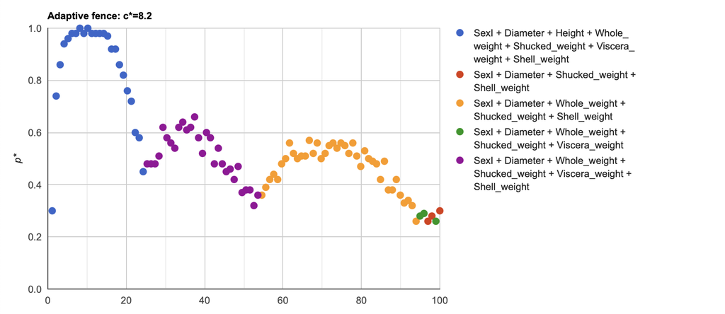

Adaptive fence

## Model Stability - Model Stability Plots

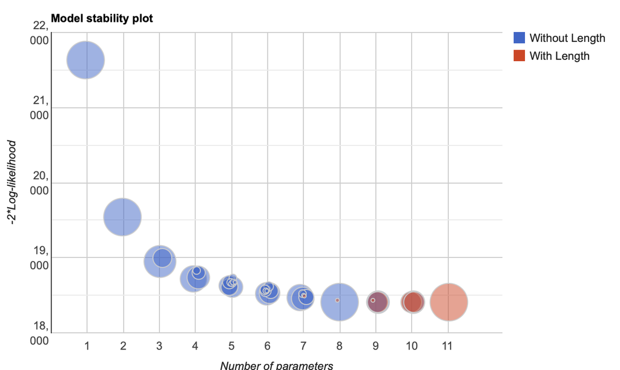

Model stability

## Overall Findings and Limitations

- **Findings:**
  - **Selection Methods:** Forward Selection (AIC/BIC) and Backward Elimination (AIC/BIC) demonstrated similar performance metrics (RMSE, MAE, R-squared).
  - Displays the best performance.
  - **Intuitive Model:** Exhibited slightly higher RMSE and MAE compared to selection-based models, indicating reduced precision.
- **Limitations:**
  - **Normality, Homoscedasticity & Independence:** Residuals does not fully meet normality and constant variance assumptions. We don’t know if the obervations were recorded independently.
  - **Dataset Specificity:** Models trained on the current dataset may not perform equally well on different abalone populations or environments.
  - **High Correlations:** Some predictors exhibit high multicollinearity, complicating coefficient interpretation and inflating variance.

## Practical Implications and Future Research

- **Implications:**
  - **Increased Precision:** Lower RMSE and MAE shown through our selection models ensure more accurate age predictions.
  - **Sustainable Harvesting:** Accurate age estimates assist in managing abalone populations, preventing overfishing and ensuring long-term sustainability.
  - **Economic Efficiency:** Precise age determination supports optimal harvesting schedules, maximising yield and profitability.
- **Future Endeavours:**
  - **More Environmental Factors:** Explore other weather patterns, water temperature, salinity, habitat conditions and food availability.
  - **Enhance Multicollinearity Management:** Applying regularisation methods such as Ridge or Lasso regression improving model stability and interpretability.